Norwegian Salmonid Data · Jan 2020 – Dec 2025

# Salmonid Mortality

Source data: Norwegian Veterinary Institute · [Laksetap dashboard](https://apps.vetinst.no/laksetap/)

Prepared by [Charles O.](https://www.linkedin.com/in/charlesonyegbado/)

## What this brief shows

- Mortality changes over time and follows a seasonal pattern.
- Regional differences are visible, especially for salmon.
- Deaths dominate total losses, but `other` and `discarded` losses are still important.

This brief examines salmonid losses in Norway from January 2020 to December 2025, focusing on three practical questions: how mortality changes over time, how it varies across regions, and whether non-death losses are large enough to matter.

The main message is straightforward. Mortality is not stable, it is not evenly distributed, and it is not the whole story of loss.

## 01 Mortality changes through the year

Rainbow trout and salmon do not follow the same seasonal pattern. Rainbow trout tends to build through the summer and peak in late summer or early autumn. Salmon is generally highest in winter and early spring, then lower in summer.

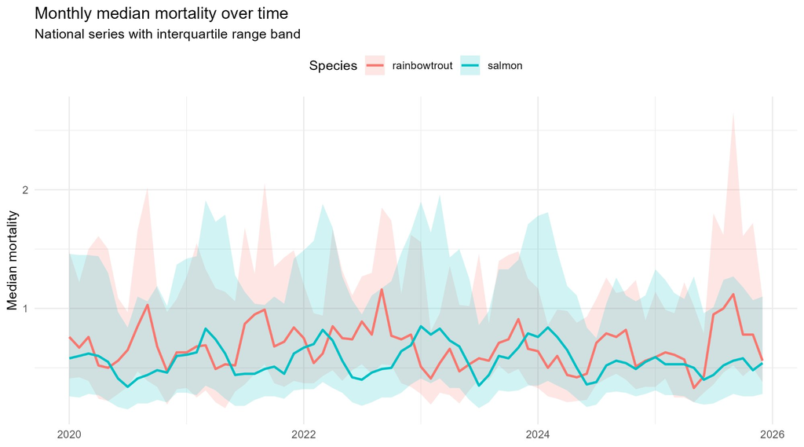

National monthly mortality changes across the full period for both species.

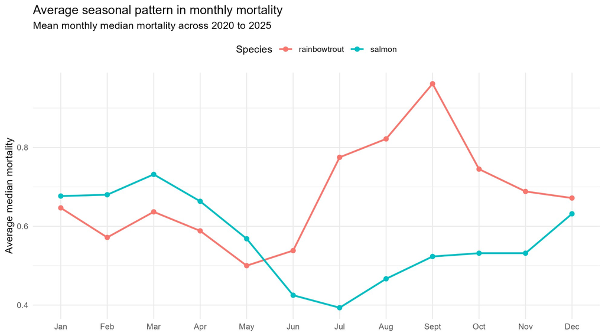

The seasonal pattern differs by species, with rainbow trout peaking later in the year than salmon.

This suggests that risk is shaped by time of year, and that timing is likely to matter differently for different species.

## 02 Place matters too

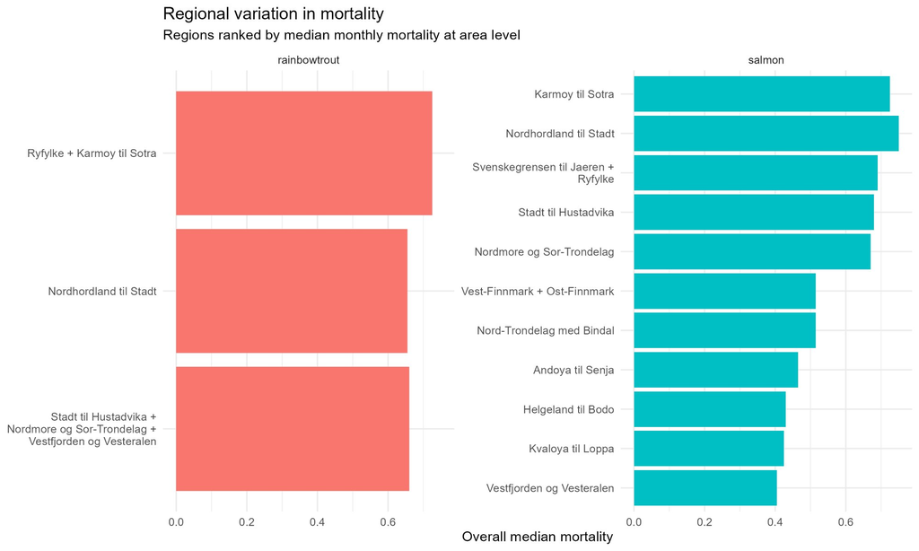

Area-level mortality is not evenly distributed, particularly for salmon.

This does not explain why the differences exist. But it shows that geography should not be treated as background context.

## 03 Losses are broader than mortality alone

Deaths account for most recorded losses, but they do not capture everything. The `other` category accounts for nearly one in ten recorded losses overall, and `discarded` losses add a further share. `Escaped` losses are much smaller by comparison.

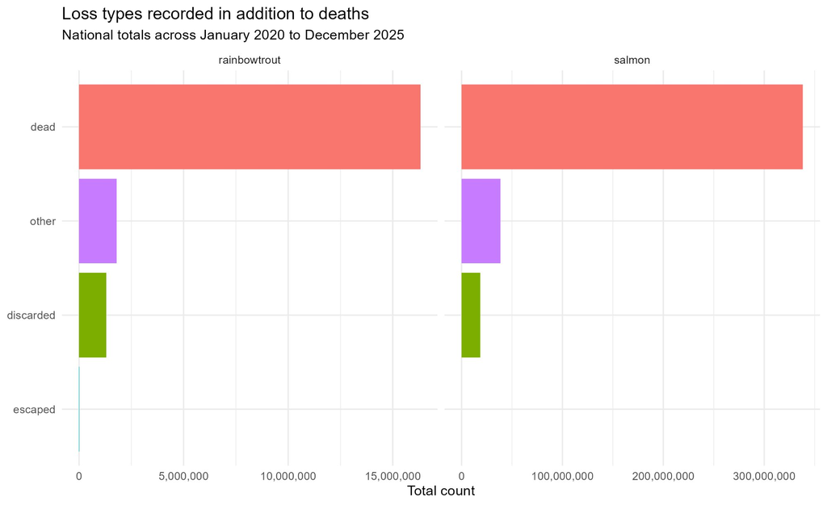

`Other` is the largest non-death loss category overall.

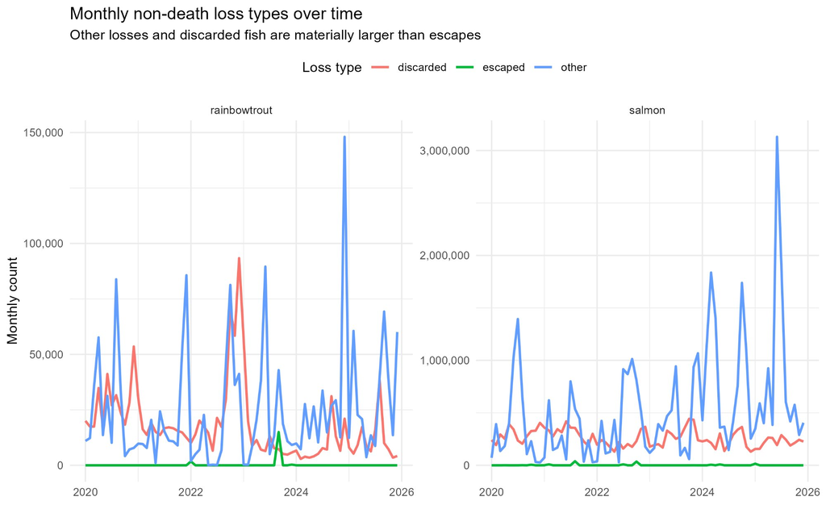

Some non-death categories show sharp monthly spikes, especially `other` losses for salmon.

This matters because focusing only on deaths would understate the wider burden of loss.

## What to take from this

📅

Timing matters

📍

Place matters

📋

The full loss profile matters

These findings are descriptive. They show what is happening in the recorded data, but they do not explain why. Differences in reporting, classification, and region definitions may also affect the patterns observed.